# Category Information with Neurosynth ROIs in the Duke Dataset

Zarrar Shehzad

February 8th, 2016

Our goal for this script is to generate plots comparing the patterns of activity between pairs of categories for every neurosynth based ROI.

We generate outputs for the ‘group-average’ thresholded for significant results as well as the percent correct category detection measure.

Note that this builds on `12_neurosynth_partial_correlations.R`.

## 0.1 Load

### 0.1.1 Packages

using dev version of ggplot?? install_github(“hadley/scales”) install_github(“hadley/ggplot2”)

```r
if (!any(.libPaths() == "/home/zshehzad/R_libs")) .libPaths(c("~/R_libs", .libPaths()))
library(plyr)
library(ggplot2)
library(RColorBrewer)
suppressMessages(require(grid))
suppressMessages(require(gridExtra))
suppressMessages(library(niftir))
suppressMessages(library(doMC))
registerDoMC(24)
library(pander) # for tables
```

### 0.1.2 Data and Variables

We load the data and some relevant variables related to the ROIs

```r
# Set some variables first
base       <- "/data1/ffg05"
corrdir    <- file.path(base, "analysis/duke/correlation") # output directory
# Load
# note that the NULL setting is for the rstudio debugger
subjects <- NULL; roi.names <- NULL; roi.names.title <- NULL
categories <- NULL; categories.title <- NULL
ridge.grp <- NULL; ridge.subs <- NULL; ridge.detect <- NULL
load(file.path(corrdir, "neurosynth_partial_correlations.rda"))
# Setup other relevant variables
#roi.vals      <- c(10, 12, 20, 22, 30, 32, 40, 50, 52, 60, 62, 70, 72)
#roi.hemis     <- c("L", "R", "L", "R", "L", "R", "L", "L", "R", "L", "R", "L", #"R")
#roi.names     <- c("FFA", "FFA", "PPA", "PPA", "LOC", "LOC", "VWF", "V1", "V1", #"M1", "M1", "A1", "A1")
#roi.df        <- data.frame(vals=roi.vals, hemi=roi.hemis, names=roi.names,
#                            fullnames=paste(roi.hemis, roi.names))
#roi.df        <- roi.df[-1,] # remove L FFA since it's small
```

## 0.2 Functions

Any functions that we need. Here only the generic plot theme.

```r
mytheme <- theme_minimal(14) +
  theme(axis.ticks = element_blank(),
        panel.grid.major = element_blank(),
        axis.title = element_blank())
```

## 0.3 Select Data

```r
sinds <- roi.names.title %in% c("R FFA", "R PPA", "R LOC", "L VWF", "L V1", "L M1", "L A1")
# subject
subset.ridge.subs <- ridge.subs[,sinds,,,]
dimnames(subset.ridge.subs)$roi <- sub("[LR] ", "", roi.names.title[sinds])
# group
subset.ridge.grp <- ridge.grp[sinds,,,]
dimnames(subset.ridge.grp)$roi <- sub("[LR] ", "", roi.names.title[sinds])
# detect
subset.ridge.detect <- ridge.detect[,sinds,]
dimnames(subset.ridge.detect)$roi <- sub("[LR] ", "", roi.names.title[sinds])
```

## 0.4 Format Data

### 0.4.1 Group Average Results

We want to format our partial correlations into a dataframe for easier analysis. In the process, we also need to correct for multiple comparisons and add two new variables: - category.pair (same or different) - region.type (visual or control)

```r
# Convert to a dataframe
gdf <- reshape2::melt(subset.ridge.grp[,,,1], value.name="cor")
gdf$zval <- reshape2::melt(subset.ridge.grp[,,,2])$value
gdf <- subset(gdf, select=c("roi", "even", "odd", "cor", "zval"))
# correct for multiple comparisons
gdf$fdr.pval <- p.adjust(pt(gdf$zval, Inf, lower.tail=F), "fdr")
gdf$thr.cor <- gdf$cor * (gdf$fdr.pval < 0.05)
gdf$thr.cor[gdf$thr.cor==0] <- NA # so the 0 box is blank when displaying plots
# reorder for better display (face first)
gdf$even <- factor(as.character(gdf$even),
                  levels=rev(levels(gdf$even)))
# add the category pair column
gdf$category.pair <- "different"
gdf$category.pair[gdf$even==gdf$odd] <- "same"
gdf$category.pair <- factor(gdf$category.pair)
## reorder for better display
gdf$category.pair <- factor(as.character(gdf$category.pair),
                            levels=rev(levels(gdf$category.pair)))
# add the region type column
gdf$region.type <- "visual"
gdf$region.type[gdf$roi %in% c("M1", "A1")] <- "control"
gdf$region.type <- factor(gdf$region.type)
## reorder for better display
gdf$region.type <- factor(as.character(gdf$region.type),
                          levels=rev(levels(gdf$region.type)))
# rearrange columns
gdf <- gdf[,c("region.type", "roi", "category.pair", "even", "odd",
            "cor", "zval", "fdr.pval", "thr.cor")]
```

### 0.4.2 Subject Results

```r
sdf <- reshape2::melt(subset.ridge.subs[,,,,1], value.name="cor")     # Convert to a dataframe
# Fischer-z transform
sdf$fisherz <- atanh(sdf$cor)
sdf$fisherz[is.infinite(sdf$fisherz)] <- atanh(0.999)
# Z-values
sdf$zval <- reshape2::melt(subset.ridge.subs[,,,,2])$value
# add the category pair column
sdf$category.pair <- "different"
sdf$category.pair[sdf$even==sdf$odd] <- "same"
sdf$category.pair <- factor(sdf$category.pair)
## reorder for better display
sdf$category.pair <- factor(as.character(sdf$category.pair),
                            levels=rev(levels(sdf$category.pair)))
# add the region type column
sdf$region.type <- "visual"
sdf$region.type[sdf$roi %in% c("M1", "A1")] <- "control"
sdf$region.type <- factor(sdf$region.type)
## reorder for better display
sdf$region.type <- factor(as.character(sdf$region.type),
                          levels=rev(levels(sdf$region.type)))
# reorder columns
sdf <- sdf[,c("subjects", "region.type", "roi", "category.pair", "even", "odd",
              "cor", "fisherz", "zval")]
head(sdf)
```

```
##   subjects region.type roi category.pair  even   odd        cor    fisherz
## 1    44172      visual FFA          same Faces Faces -0.2232769 -0.2271023
## 2    44179      visual FFA          same Faces Faces  0.6558165  0.7854373
## 3    44208      visual FFA          same Faces Faces  0.4248981  0.4536542
## 4    44211      visual FFA          same Faces Faces  0.4613160  0.4989817
## 5    44224      visual FFA          same Faces Faces  0.4693740  0.5092671
## 6    44242      visual FFA          same Faces Faces  0.6199845  0.7249798
##        zval
## 1 -1.158465
## 2  4.243924
## 3  1.549460
## 4  2.304522
## 5  2.009681
## 6  3.555833
```

### 0.4.3 Category Detection Results

```r
ddf <- reshape2::melt(subset.ridge.detect, value.name="accuracy")
# get the average and standard-deviation of the accuracy
# as well as the p-value using a binomial test
ddf <- ddply(ddf, .(roi, category), function(x) {
  xmean <- mean(x$accuracy)
  xsd   <- sd(x$accuracy)
  xpval <- binom.test(sum(x$accuracy), 20, p=0.25, alternative="greater")$p.value
  data.frame(mean=xmean, sd=xsd, pvalue=xpval)
})
# correct for multiple comparisons using fdr
ddf$fdr.pvalue <- p.adjust(ddf$pvalue, method="fdr")
sum(ddf$pvalue < 0.05); sum(ddf$fdr.pvalue < 0.05)
```

```
## [1] 16
```

```
## [1] 13
```

```r
# ok so let's see what we've got
head(ddf)
```

```
##   roi category mean        sd       pvalue   fdr.pvalue
## 1 FFA    Faces 0.75 0.4442617 3.813027e-06 5.338238e-05
## 2 FFA   Fruits 0.70 0.4701623 2.951175e-05 1.652658e-04
## 3 FFA  Letters 0.50 0.5129892 1.386442e-02 2.986182e-02
## 4 FFA Vehicles 0.30 0.4701623 3.828273e-01 4.122756e-01
## 5 PPA    Faces 0.55 0.5104178 3.942142e-03 1.226444e-02
## 6 PPA   Fruits 0.70 0.4701623 2.951175e-05 1.652658e-04
```

## 0.5 Unique Information

First we analyze and plot the amount of unique information (correlation) for each category.

### 0.5.1 Visual Areas for Same Categories

#### 0.5.1.1 ANOVA

Our first analysis is an ANOVA to see if the correlations vary by region. If the information is evenly distributed, then it shouldn’t matter which region we sample.

```r
# Setup the dataframe
dat <- subset(sdf, category.pair=="same")    # Select only same category pairs
dat$category <- dat$even        # Category column (even/odd same)
# Focus for now on visual areas
dat <- subset(dat, region.type=="visual")
dat$roi <- factor(dat$roi)
# Select columns
dat <- subset(dat, select=c("subjects", "roi", "category", "cor", "fisherz", "zval"))
# Run the anova but only within the visual areas
fit <- aov(fisherz ~ roi*category + Error(subjects), data=dat)
res <- summary(fit)
# for plotting in latex
xtable::xtable(res, digits=c(0,0,2,2,1,3))
```

```
## % latex table generated in R 3.2.2 by xtable 1.7-4 package
## % Tue Feb  9 14:03:05 2016
## \begin{table}[ht]
## \centering
## \begin{tabular}{lrrrrr}
##   \hline
##  & Df & Sum Sq & Mean Sq & F value & Pr($>$F) \\
##   \hline
## Residuals & 1 & 0.00 & 0.00 &  &  \\
##   roi          & 4 & 1.52 & 0.38 & 3.4 & 0.010 \\
##   category     & 3 & 2.32 & 0.77 & 6.8 & 0.000 \\
##   roi:category & 12 & 1.24 & 0.10 & 0.9 & 0.534 \\
##   Residuals    & 379 & 42.93 & 0.11 &  &  \\
##    \hline
## \end{tabular}
## \end{table}
```

We can see that the main effects of ROI and category are significant but the interaction effect.

```r
panderOptions("digits", 2)
pander(res)
```

|  | Df | Sum Sq | Mean Sq | F value | Pr(>F) |
| --- | --- | --- | --- | --- | --- |
| **Residuals** | 1 | 0.0014 | 0.0014 | NA | NA |
| **roi** | 4 | 1.5 | 0.38 | 3.4 | 0.01 |
| **category** | 3 | 2.3 | 0.77 | 6.8 | 0.00017 |
| **roi:category** | 12 | 1.2 | 0.1 | 0.91 | 0.53 |
| **Residuals** | 379 | 43 | 0.11 | NA | NA |

```r
# maybe for later?
# ddply(sdf, .(roi), colwise(function(x) tanh(mean(x)), .(fisherz)))
# ddply(sdf, .(roi), colwise(function(x) tanh(sd(x)), .(cor)))
```

#### 0.5.1.2 Plots

We can now plot the information for each same category pair. Note that here we are using the group-average correlation results that I have calculated. Also note that we will plot both the visual and the control regions here.

First, we plot the within-category information for each region and category.

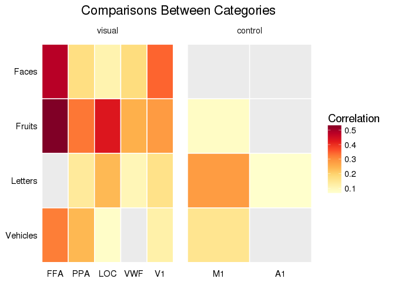

```r
# select only same category pairs
dat <- subset(gdf, category.pair=="same")
names(dat)[4] <- "category"
dat <- dat[,-5]
# finally plot
p <- ggplot(dat, aes(roi, category, fill = thr.cor)) +
  geom_tile(colour="white", size=0.5) +
  scale_fill_gradientn(name="Correlation",
                       colours=brewer.pal(9,"YlOrRd"),
                       na.value="grey92") +
  ggtitle("Comparisons Between Categories") +
  xlab("Brain Regions") +
  ylab("") + facet_grid(.~region.type, scales="free_x") +
  mytheme #+
#theme(axis.text.x = element_blank())
plot(p)
```

### 0.5.2 Visual vs Control Regions for Same Category

Let’s also look at the comparison between the control regions and visual regions.

```r
dat <- subset(sdf, category.pair=="same")    # Select only same category pairs
dat$category <- dat$even        # Category column (even/odd same)
# Select columns
dat <- subset(dat, select=c("subjects", "region.type", "roi", "category", "cor", "fisherz", "zval"))
# ANOVA result
fit <- aov(fisherz ~ region.type*category + Error(subjects), data=dat)
res <- summary(fit)
# for plotting in latex
xtable::xtable(res, digits=c(0,0,2,2,1,3))
```

```
## % latex table generated in R 3.2.2 by xtable 1.7-4 package
## % Tue Feb  9 14:03:06 2016
## \begin{table}[ht]
## \centering
## \begin{tabular}{lrrrrr}
##   \hline
##  & Df & Sum Sq & Mean Sq & F value & Pr($>$F) \\
##   \hline
## Residuals & 1 & 0.04 & 0.04 &  &  \\
##   region.type          & 1 & 2.03 & 2.03 & 20.6 & 0.000 \\
##   category             & 3 & 1.62 & 0.54 & 5.5 & 0.001 \\
##   region.type:category & 3 & 0.90 & 0.30 & 3.0 & 0.029 \\
##   Residuals            & 551 & 54.43 & 0.10 &  &  \\
##    \hline
## \end{tabular}
## \end{table}
```

```r
panderOptions("digits", 2)
pander(res)
```

|  | Df | Sum Sq | Mean Sq | F value | Pr(>F) |
| --- | --- | --- | --- | --- | --- |
| **Residuals** | 1 | 0.043 | 0.043 | NA | NA |
| **region.type** | 1 | 2 | 2 | 21 | 7.1e-06 |
| **category** | 3 | 1.6 | 0.54 | 5.5 | 0.0011 |
| **region.type:category** | 3 | 0.9 | 0.3 | 3 | 0.029 |
| **Residuals** | 551 | 54 | 0.099 | NA | NA |

## 0.6 Categorization Accuracy

### 0.6.1 ANOVA

Actually, let’s ignore this section and focus on the plot.

```r
dat <- reshape2::melt(subset.ridge.detect, value.name="accuracy")
dat$region.type <- "visual"
dat$region.type[dat$roi %in% c("M1", "A1")] <- "control"
dat$region.type <- factor(dat$region.type)
# Run the anova but only within the visual areas
#fit <- glm(accuracy ~ roi*category + Error(subjects), family=binomial(), data=dat)
#fit <- aov(accuracy ~ roi*category + Error(subjects), data=subset(dat, region.type=="visual"))
#res <- summary(fit)
#res
# for plotting in latex
#xtable::xtable(res, digits=c(0,0,2,2,1,3))
```

### 0.6.2 Table

This should be the table showing all that we need.

```r
mean.arr <- reshape2::acast(ddf, roi ~ category, value.var="mean")
pval.arr <- reshape2::acast(ddf, roi ~ category, value.var="fdr.pvalue")
mat <- matrix(sprintf("%i%s", mean.arr*100, gsub(" ", "", add.significance.stars(pval.arr))),
              nrow(mean.arr), ncol(mean.arr), dimnames=dimnames(mean.arr))
```

```r
pandoc.table(mat,
             caption = "Shows the average categorization accuracy across subjects.")
```

Shows the average categorization accuracy across subjects.

|  | Faces | Fruits | Letters | Vehicles |
| --- | --- | --- | --- | --- |
| **FFA** | 75*** | 70*** | 50* | 30 |
| **PPA** | 55* | 70*** | 40 | 60** |
| **LOC** | 35 | 75*** | 45 | 30 |
| **VWF** | 35 | 50* | 45 | 25 |
| **V1** | 70*** | 60** | 40 | 50* |
| **M1** | 35 | 30 | 60** | 35 |
| **A1** | 45 | 25 | 50* | 30 |